# Auto Insurance Pricing Demo

Nathan Lally

November 3, 2018

# 1 A Very, Very Short Primer on Insurance Pricing

To set the price of most products or services, the formula is relatively simple.

$$\begin{align}
\text{Price} &= \text{Cost} + \text{Desired Profit}
\end{align}$$
Where, **cost** is the amount of money it costs to manufacture, deliver, market, etc. a product or service and **desired profit** is the amount of extra money the seller decides to charge (based on supply and demand).

The cost of most goods and services is fairly well known. We know how much we paid for raw materials, about how much labor will cost, and have a good grasp of other expenses we may incur. We could say that cost is mostly **deterministic**.

Insurance, however, is quite different than most products or services. Before we sell you an insurance contract, we do not know how much you will ultimately will cost us. The best we can do is make an educated guess based on traits you share with our other customers (both current and historical) and other variables related to the insurance marketplace.

The price you pay for an insurance contract is called a **premium** and can be decomposed into several pieces.

$$\text{Premium} = \text{Pure Premium} + (\text{Fixed Expenses,Profit,Etc...})\\
\text{where}\\
\text{Pure Premium} = (\text{Expected Claim Frequency})\cdot(\text{Expected Claim Cost})\\$$

Where **pure premium** is the amount of money we (the insurer) expect you to cost us in claims. Pure premium is not deterministic, instead it is a **random quantity** that must be estimated. Insurance companies use statistical and machine learning models to estimate pure premium. It is the job of the statistician/data scientist to construct the models and tools used for this estimation.

There are two ways to model pure premium,

1. Model claim frequency and claim cost separately. The product of the two results is pure premium.
2. Model pure premium directly (often using a compound distribution).

The next several sections in this document walk you through an example data analysis of claims frequency using auto insurance claims data from France in the year 2004. We will model claim frequency as it is more interesting than claim cost which is typically a function of the value of the car and regional economics.

Why France in 2004? Because someone kindly made this data [publicly and freely available](http://cas.uqam.ca/). Most insurers are reluctant or unable to share their data with the public.

# 2 Obtain & Manipulate Data

```r
# fetch claims and claims severity data, join them so we can model pure premium
data(freMPL1)
df <- as_tibble(freMPL1)
df <- df %>%
  select(Exposure,ClaimInd,LicAge,VehAge,Gender,VehUsage,DrivAge,VehBody,VehMaxSpeed)
rm(freMPL1)
```

# 3 Data Analysis

## 3.1 Step 1: Exploratory Data Analysis

### 3.1.1 Numerical Summaries

```r
# some simple statistics
cat("The total sample size is\n", nrow(df))
```

```
## The total sample size is
##  30595
```

```r
cat("There are a total of\n", ncol(df)-2, "\npredictor varaibles available")
```

```
## There are a total of
##  7
## predictor varaibles available
```

```r
cat("There are a total of\n", sum(df$ClaimInd), "\nobserved claims")
```

```
## There are a total of
##  3265
## observed claims
```

```r
cat("The overall claims frequency is ", round(sum(df$ClaimInd)/sum(df$Exposure),4))
```

```
## The overall claims frequency is  0.2385
```

```r
# here is a quick snapshot of the data
glimpse(df)
```

```
## Observations: 30,595
## Variables: 9
## $ Exposure    <dbl> 0.583, 0.200, 0.083, 0.375, 0.500, 0.499, 0.218, 0...
## $ ClaimInd    <int> 0, 0, 0, 0, 1, 0, 1, 0, 0, 0, 0, 0, 0, 0, 0, 0, 0,...
## $ LicAge      <int> 366, 187, 169, 170, 224, 230, 169, 232, 241, 298, ...
## $ VehAge      <fct> 2, 0, 1, 1, 3, 3, 6-7, 4, 5, 2, 2, 6-7, 2, 3, 6-7,...
## $ Gender      <fct> Female, Male, Female, Female, Male, Male, Male, Fe...
## $ VehUsage    <fct> Professional, Private+trip to office, Professional...
## $ DrivAge     <int> 55, 34, 33, 34, 53, 53, 32, 38, 39, 43, 44, 54, 54...
## $ VehBody     <fct> sedan, microvan, other microvan, other microvan, v...
## $ VehMaxSpeed <fct> 160-170 km/h, 170-180 km/h, 170-180 km/h, 170-180 ...
```

### 3.1.2 Graphics

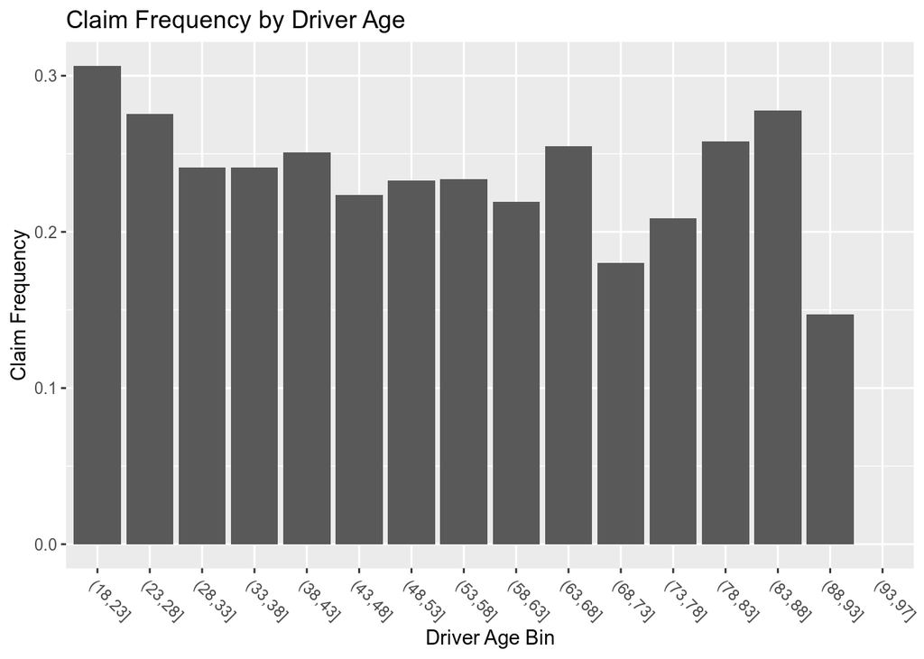

```r
# Age
df$agebins <- cut(df$DrivAge, breaks=c(seq(18,93,5),max(df$DrivAge)))
drvage <- df %>%
  group_by(agebins) %>%
  summarise(claims = sum(ClaimInd),
            exposure = sum(Exposure)) %>%
  mutate(freq = claims/exposure) %>%
  na.omit()
ageplot <- ggplot(data=drvage, aes(x=agebins, y=freq)) +
  geom_col() +
  labs(x="Driver Age Bin", y="Claim Frequency", title="Claim Frequency by Driver Age") +
  theme(axis.text.x = element_text(angle=-45, hjust=0))
ageplot
```

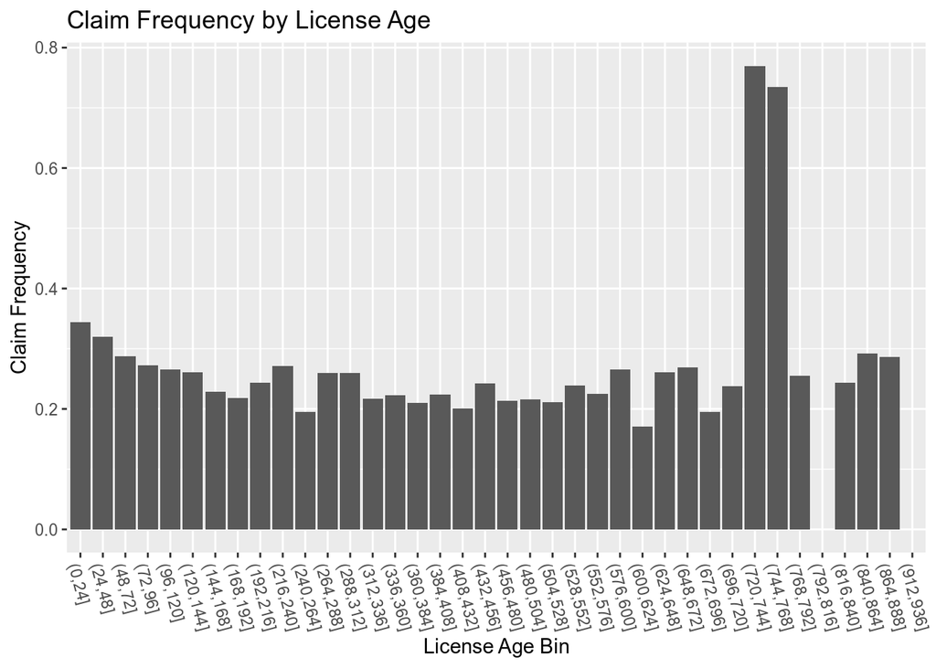

```r
# License Age
df$licbins <- cut(df$LicAge, breaks=seq(0,940,24))
licage <- df %>%
  group_by(licbins) %>%
  summarise(claims = sum(ClaimInd),
            exposure = sum(Exposure)) %>%
  mutate(freq = claims/exposure) %>%
  na.omit()
ageplot <- ggplot(data=licage, aes(x=licbins, y=freq)) +
  geom_col() +
  labs(x="License Age Bin", y="Claim Frequency", title="Claim Frequency by License Age") +
  theme(axis.text.x = element_text(angle=-75, hjust=0))
ageplot
```

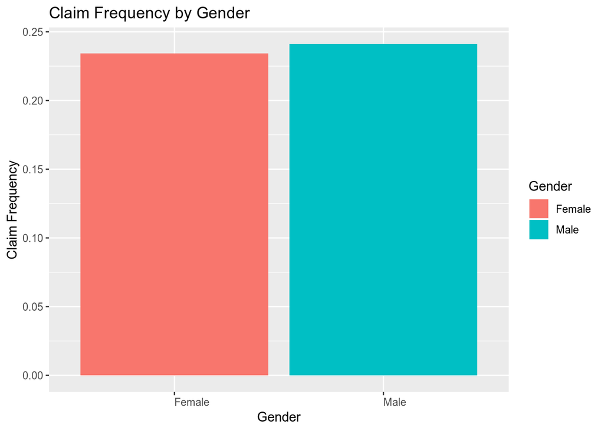

```r
# Gender
gen <- df %>%
  group_by(Gender) %>%
  summarise(claims = sum(ClaimInd),
            exposure = sum(Exposure)) %>%
  mutate(freq = claims/exposure) %>%
  na.omit()
genplot <- ggplot(data=gen, aes(x=Gender, y=freq, fill=Gender)) +
  geom_col() +
  labs(x="Gender", y="Claim Frequency", title="Claim Frequency by Gender") +
  theme(axis.text.x = element_text(angle=0, hjust=0))
genplot
```

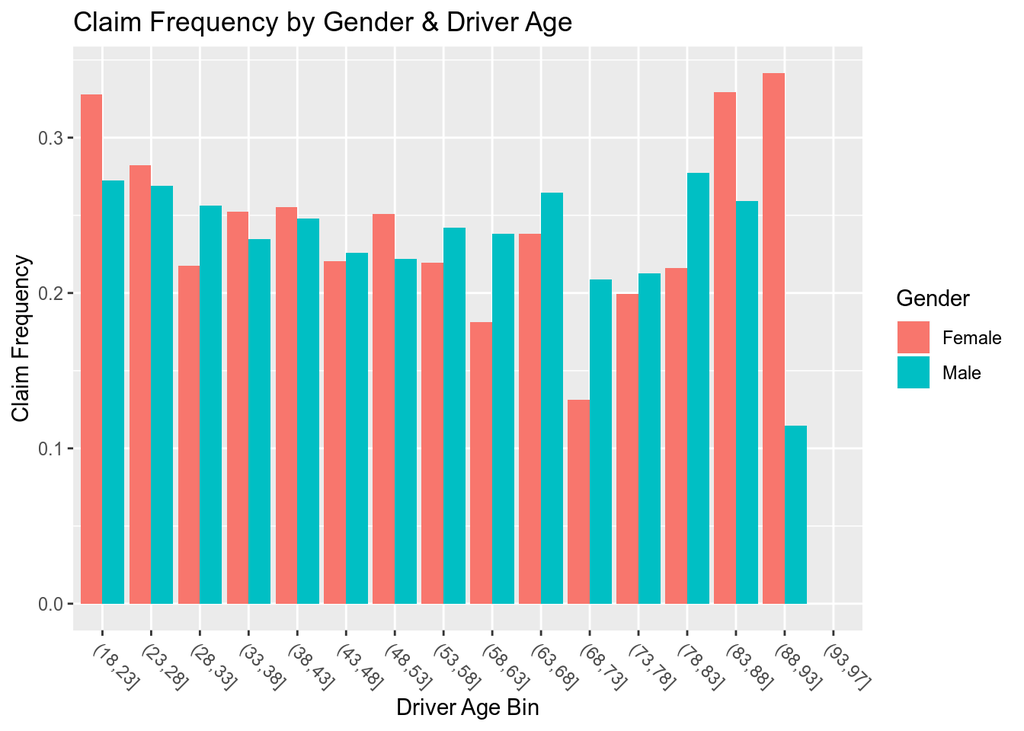

```r
# Age and Gender
agegen <- df %>%
  group_by(Gender,agebins) %>%
  summarise(claims = sum(ClaimInd),
            exposure = sum(Exposure)) %>%
  mutate(freq = claims/exposure) %>%
  na.omit()
genageplot <- ggplot(data=agegen, aes(x=agebins, y=freq, fill=Gender)) +
  geom_col(position = 'dodge') +
  labs(x="Driver Age Bin", y="Claim Frequency", title="Claim Frequency by Gender & Driver Age") +
  theme(axis.text.x = element_text(angle=-45, hjust=0))
genageplot
```

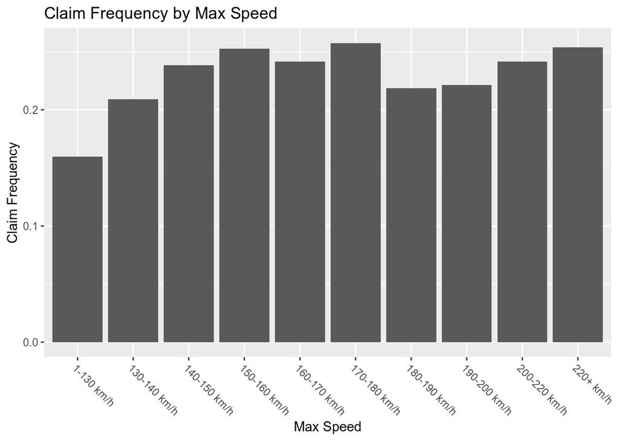

```r
# Max Speed
spd <- df %>%
  group_by(VehMaxSpeed) %>%
  summarise(claims = sum(ClaimInd),
            exposure = sum(Exposure)) %>%
  mutate(freq = claims/exposure) %>%
  na.omit()
spdplot <- ggplot(data=spd, aes(x=VehMaxSpeed, y=freq)) +
  geom_col() +
  labs(x="Max Speed", y="Claim Frequency", title="Claim Frequency by Max Speed") +
  theme(axis.text.x = element_text(angle=-45, hjust=0))
spdplot
```

## 3.2 Step 2: Fit a Predictive Model

### 3.2.1 Train the Model

```r
# set up modeling data
df <- df %>%
  select(-agebins,-licbins)
y <- df$ClaimInd
exposure <- df$Exposure
x <- df %>%
  select(-c(Exposure,ClaimInd)) %>%
  as.data.frame()
# fit
set.seed(972)
tune.grid <- expand.grid(mtry=1:ncol(x), nodesize=c(500, 750, 1000, 2000, 3000, 5000), oob=NA)
for(i in 1:nrow(tune.grid)){
  tune.grid$oob[i] <- mean(rfPoisson(y = y,
                 offset = log(exposure),
                 x = x,
                 ntree = 300)$dev)
}
tuned.hypers <- tune.grid[which(tune.grid$oob==min(tune.grid$oob)),]
m0 <-  rfPoisson(y = y,
                 offset = log(exposure),
                 x = x,
                 mtry = tuned.hypers$mtry,
                 nodesize = tuned.hypers$nodesize,
                 ntree = 300)
```

### 3.2.2 Model Results

#### 3.2.2.1 Variable Importance

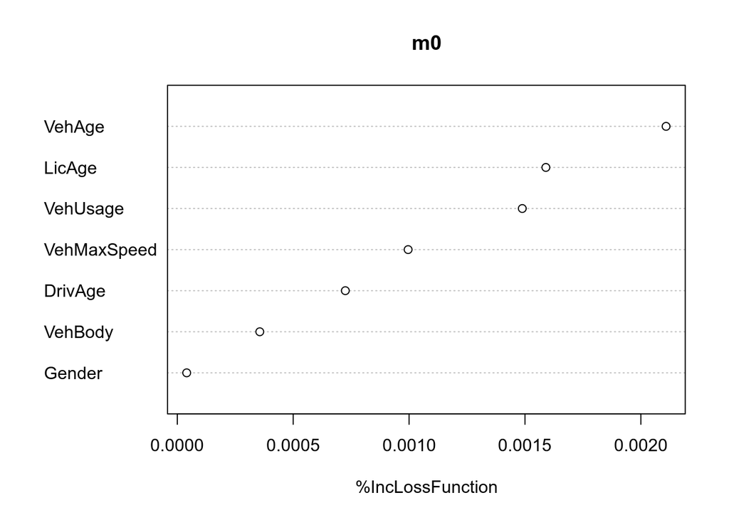

```r
varImpPlot(m0)
```

### 3.2.3 Partial Dependence

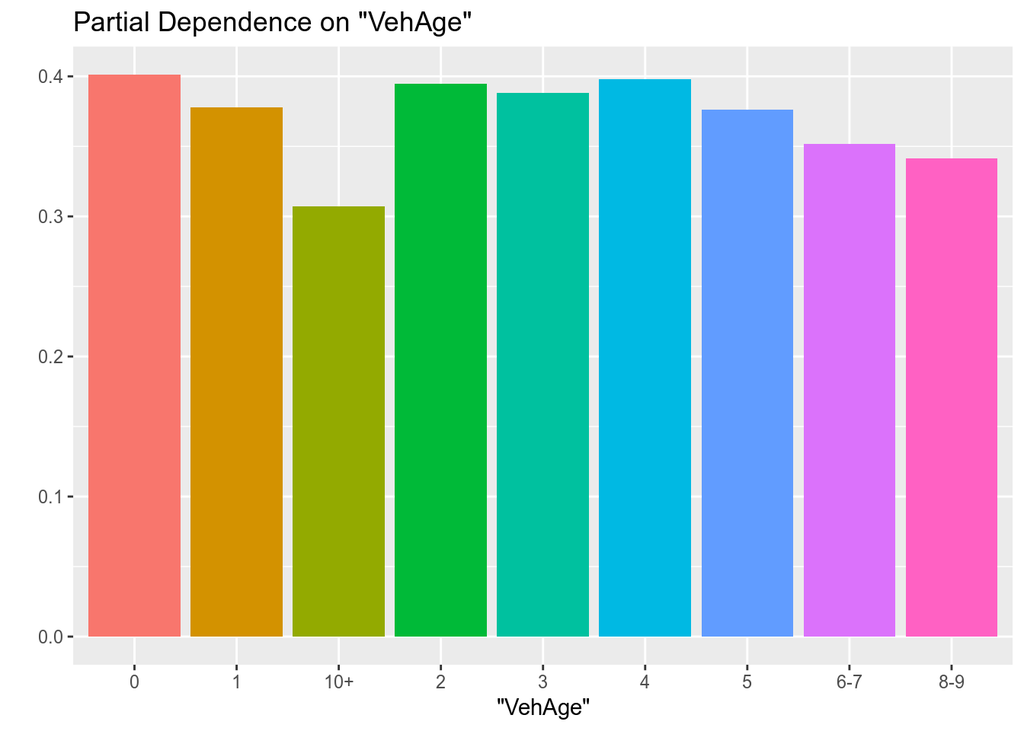

```r
partialPlot(m0, x.var = "VehAge", pred.data = x, offset = exposure)
```

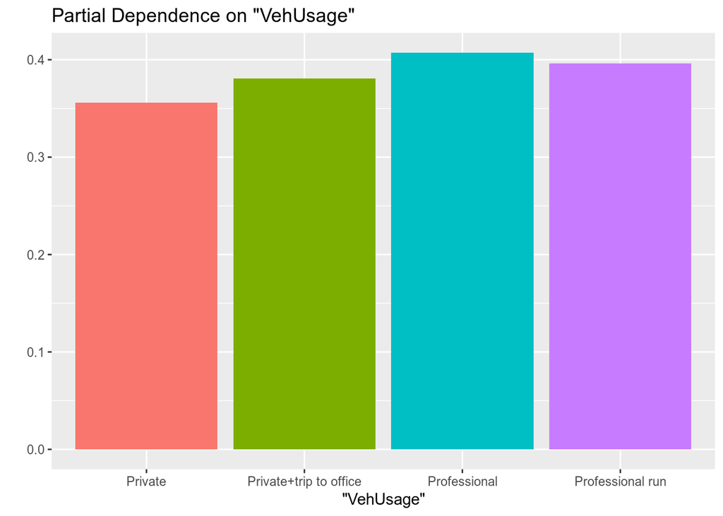

```r
partialPlot(m0, x.var = "VehUsage", pred.data = x, offset = exposure)
```

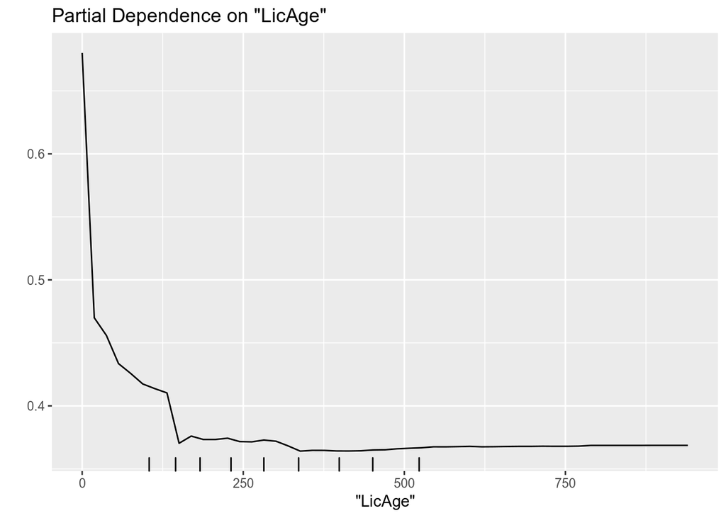

```r
partialPlot(m0, x.var = "LicAge", pred.data = x, offset = exposure)
```

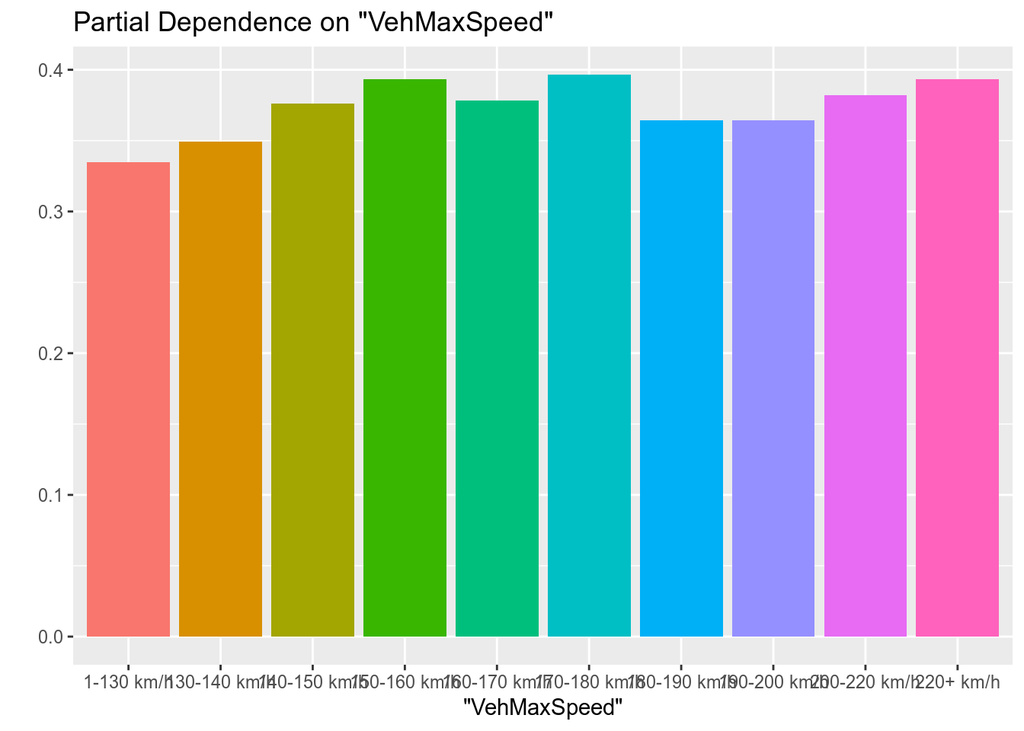

```r
partialPlot(m0, x.var = "VehMaxSpeed", pred.data = x, offset = exposure)
```

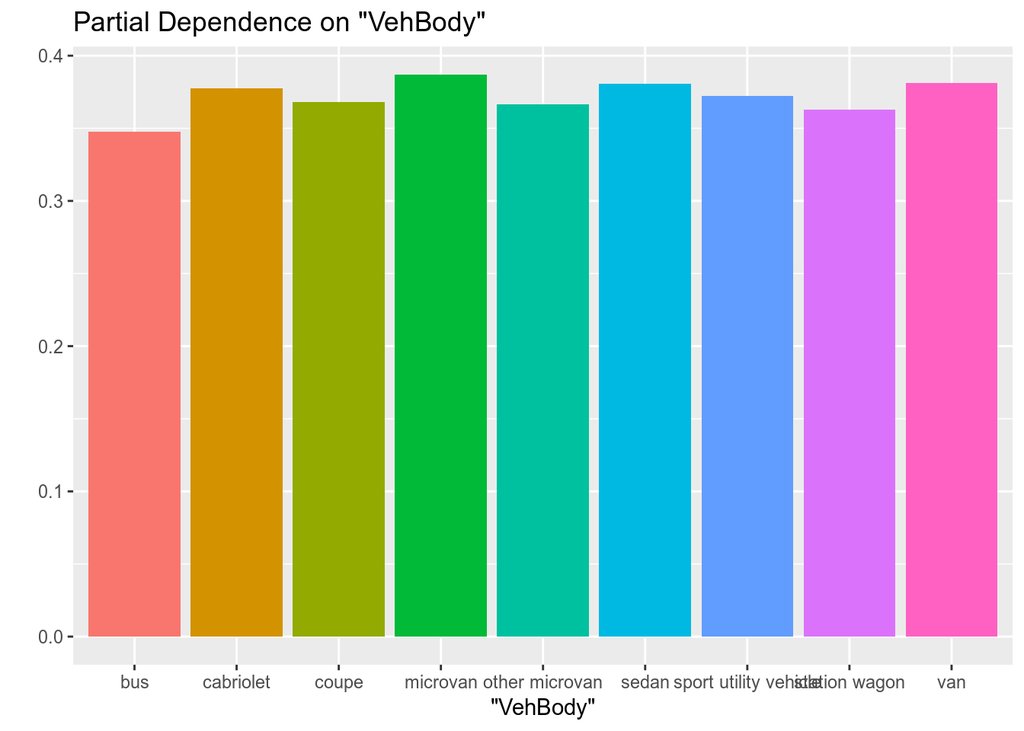

```r
partialPlot(m0, x.var = "VehBody", pred.data = x, offset = exposure)
```

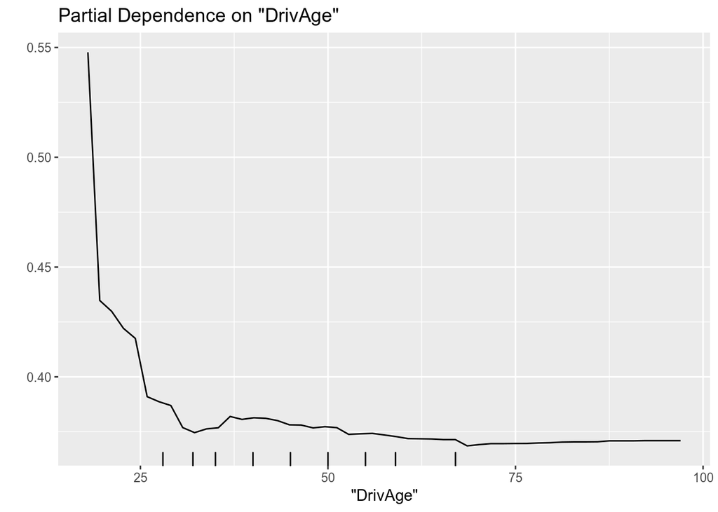

```r
partialPlot(m0, x.var = "DrivAge", pred.data = x, offset = exposure)
```

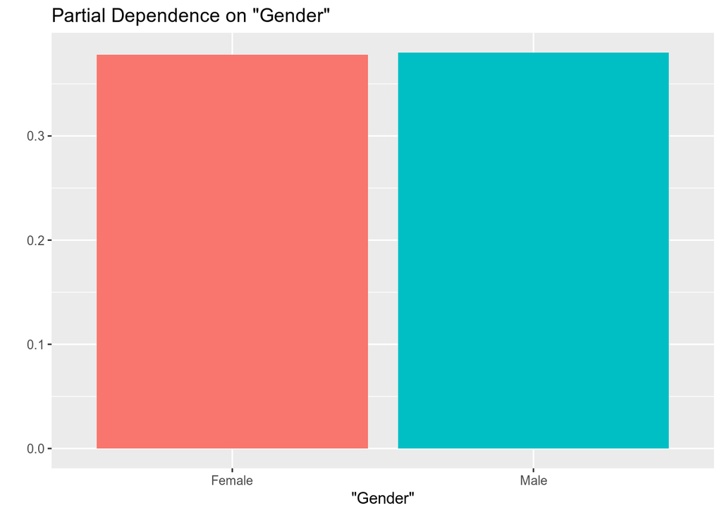

```r
partialPlot(m0, x.var = "Gender", pred.data = x, offset = exposure)
```

# 4 Build an Application